Third Week: Exploratory Data Analysis LaLiga Analysis Kayhan Momeni 4 Esfand 96

# تمرین سری سوم: از لالیگا تا لیگ برتر

> با استفاده از داده های لیگ دسته اول اسپانیا به سوالات زیر پاسخ دهید. از هر دو ابزار ggplot2 و highcharter برای تصویرسازی استفاده نمایید.

#### ۱. تعداد قهرمانی های تیم ها در تاریخ لالیگا را استخراج کرده و نمودار ستونی آنها را رسم کنید.

##### پاسخ:

ابتدا پکیج های مورد نیاز را صدا زده و داده های خود را لود می کنیم:

```r
library(dplyr)
library(engsoccerdata)
library(highcharter)
laliga = spain[which(spain$round=="league" & spain$tier==1),]
```

سپس برای هر فصل، جدول فصل را تشکیل می دهیم. رنکینگ هر تیم به این صورت است که ابتدا امتیاز آن محاسبه می شود اگر امتیازشان برابر بود، تفاضل گلشان در بازی رودررو معیار رده بندی قرار میگیرد و اگر تفاضل گل در بازی رودررو هم برابر بود، تفاضل گلشان در کل فصل محاسبه می شود:

```r
rbind(
  laliga %>%
    select(Season, Team=home, opp=visitor, GF=hgoal, GA=vgoal),
  laliga %>%
    select(Season, Team=visitor, opp=home, GF=vgoal, GA=hgoal)
) %>% mutate (GD=GF-GA) -> pl

pl %>%
  group_by(Season, Team) %>%
  summarise(Pld= n(), W = sum(GD>0), D=sum(GD==0),L=sum(GD<0),
            GF=sum(GF), GA=sum(GA), GD=sum(GD)) %>%
  mutate(Pts = 3*W + D) %>%
  arrange(-Season, -Pts, -GD) -> leagueTables

for (n in 1:20)
{
  s=TRUE
  for (i in 1:(dim(leagueTables)[1]-1))
  {
    if ((leagueTables$Season[i]==leagueTables$Season[i+1]) &
        (leagueTables$Pts[i]==leagueTables$Pts[i+1]))
    {
      pl%>%
        filter(Season==leagueTables$Season[i] &
                 Team==leagueTables$Team[i] &
                 opp==leagueTables$Team[i+1]) -> data
      GD = sum(data$GD)
      if (GD < 0)
      {
        s=FALSE
        tmp = leagueTables[i,]
        leagueTables[i,]=leagueTables[i+1,]
        leagueTables [i+1,]=tmp
      }
    }
  }
  if (s)
    break
}
leagueTables %>%
  mutate(tmp= 1) -> leagueTables

leagueTables %>%
  group_by(Season) %>%
  mutate(Pos= cumsum(tmp)) -> leagueTables

leagueTables$tmp=NULL

rm (data, tmp, GD, i, n)
```

سپس باید برای هر فصل، قهرمانش را حساب کنیم:

```r
leagueTables %>%
  group_by(Season) %>%
  slice(1) -> Champions
```

در نهایت می توانیم تعداد قهرمانی های هر تیم را شمرده و در نمودار ستونی رسم کنیم:

```r
Champions %>%
  group_by(Team) %>%
  summarise(Count=n()) %>%
  arrange(-Count) %>%
  hchart(type="column", hcaes(x=Team, y=Count), name="Number of Winning Seasons") %>%
  hc_add_theme(hc_theme_elementary() )
```

[interactive chart not shown]

برای رسم همین نمودار با پکیج ggplot خواهیم داشت:

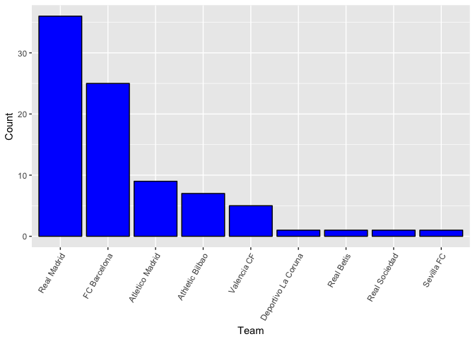

```r
library(ggplot2)
Champions %>%
  group_by(Team) %>%
  summarise(Count=n()) %>%
  arrange(-Count) -> tmp
tmp$Team <- factor(tmp$Team, levels=tmp$Team[1:dim(tmp)[1]])
plot=ggplot(data=tmp, aes(x=Team, y=Count))
plot + geom_bar(stat = "identity", fill="blue", color="black")+
  theme(axis.text.x=element_text(angle=60, hjust=1))
```

#### ۲. کسل کننده ترین لیگ و تیم را بیابید. نمودار ده تیم و ده فصل کسل کننده را رسم کنید.

##### پاسخ:

اختتلاف زیاد بین امتیاز تیم ها، معیاری برای کسل کننده بودن لیگ است. همچنین اگر این اختلاف زیاد، در رتبه های بالاتر جدول رخ دهد، میزان کسالت آوری آن بیشتر است. بنابر این حواس خود را به ۴ تیم اول جدول معطوف می کنیم. اگر اختلاف امتیاز تیم اول و دوم را با dif1 و اختلاف امتیاز بین تیم دوم و سوم را با dif2 و اختلاف امتیاز بین تیم سوم و چهارم را با dif3 نشان دهیم، میزان کسالت آوری هذ فصل را به این صورت تعریف می کنیم:

$Boringness=(3*dif1) + (2*dif2) + (1*dif3)$

حالا می توانیم برای هر فصل میزان کسالت آوری آن را حساب کنیم:

```r
Champions %>%
  mutate(diffOf1and2=Pos, diffOf2and3=Pos, diffOf3and4=Pos, Boringness=Pos) -> Champions

for (i in 1:dim(Champions)[1])
{
  season = Champions$Season[i]
  diff1 = leagueTables[which(leagueTables$Season==season & leagueTables$Pos==1),"Pts"] -
          leagueTables[which(leagueTables$Season==season & leagueTables$Pos==2),"Pts"]
  Champions$diffOf1and2[i] = diff1
  diff2 = leagueTables[which(leagueTables$Season==season & leagueTables$Pos==2),"Pts"] -
          leagueTables[which(leagueTables$Season==season & leagueTables$Pos==3),"Pts"]
  Champions$diffOf2and3[i] = diff2
  diff3 = leagueTables[which(leagueTables$Season==season & leagueTables$Pos==3),"Pts"] -
          leagueTables[which(leagueTables$Season==season & leagueTables$Pos==4),"Pts"]
  Champions$diffOf3and4[i] = diff3
  Champions$Boringness[i]  = (3*diff1) + (2*diff2) + (diff3)
}
rm(diff1, diff2, diff3, i, season)

Champions %>%
  arrange(-as.integer(Boringness)) %>%
  select(Season, Champion=Team) %>%
  head(1)
```

```
## # A tibble: 1 x 2
## # Groups:   Season [1]
##   Season Champion
##    <dbl> <chr>
## 1   2011 Real Madrid
```

همانطور که مشخص است، کسل کننده ترین فصل در لالیگا، فصل ۲۰۱۱ بوده است که رئال مادرید با اختلاف ۹ امتیاز از بارسلونا اول شد و بارسلونا با اختلاف ۳۰ امتیاز از والنسیا دوم شد و والنسیا هم در رده ی سوم ایستاد. نمودار ده تا از کسل کننده ترین فصل های لالیگا هم به این صورت است:

```r
Champions %>%
  arrange(-as.integer(Boringness)) %>%
  .[1:10,] %>%
  hchart(type="column", hcaes(x=Season, y=Boringness), name="Boringness") %>%
  hc_add_theme(hc_theme_elementary())
```

[interactive chart not shown]

برای رسم همین نمودار با پکیج ggplot خواهیم داشت:

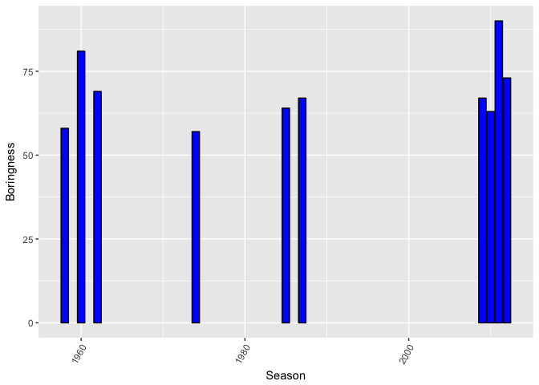

```r
Champions %>%
  arrange(-as.integer(Boringness)) -> Champions
tmp = Champions[1:10,]
tmp$Boringness=as.numeric(tmp$Boringness)
plot=ggplot(data=tmp, aes(x=Season, y=Boringness))
plot + geom_bar(stat = "identity", fill="blue", color="black")+
  theme(axis.text.x=element_text(angle=60, hjust=1))
```

برای پیدا کردن کسل کننده ترین تیم هم می توان متوسط تعداد گل های زده ی هر تیم را در هر بازی حساب کرد. هرچه این عدد کمتر باشد، کسالت آوری آن تیم بیشتر است. بنابراین معکوس این کمیت را به عنوان معیار کسالت آوری هر تیم در نظر می گیریم:

```r
pl %>%
  group_by(Team) %>%
  summarise(Pld= n(), GF=sum(GF), GA=sum(GA)) %>%
  mutate(GFperMatch = GF/Pld, Boringness = 1/GFperMatch) %>%
  arrange(-Boringness) -> Teams

Teams %>%
  select(Team, GFperMatch) %>%
  head(1)
```

```
## # A tibble: 1 x 2
##   Team           GFperMatch
##   <chr>               <dbl>
## 1 CF Extremadura      0.775
```

همانطور که مشخص است، تیم CF Extremadura که به طور متوسط ۰.۷۷۵ گل در هر بازی زده است، کسالت آور ترین تیم لیگ اسپانیا است. نمودار ده تیم کسالت آور برتر به این صورت است:

```r
Teams %>%
  arrange(-as.integer(Boringness)) %>%
  .[1:10,] %>%
  hchart(type="column", hcaes(x=Team, y=Boringness), name="Boringness") %>%
  hc_add_theme(hc_theme_elementary())
```

[interactive chart not shown]

برای رسم همین نمودار با پکیج ggplot خواهیم داشت:

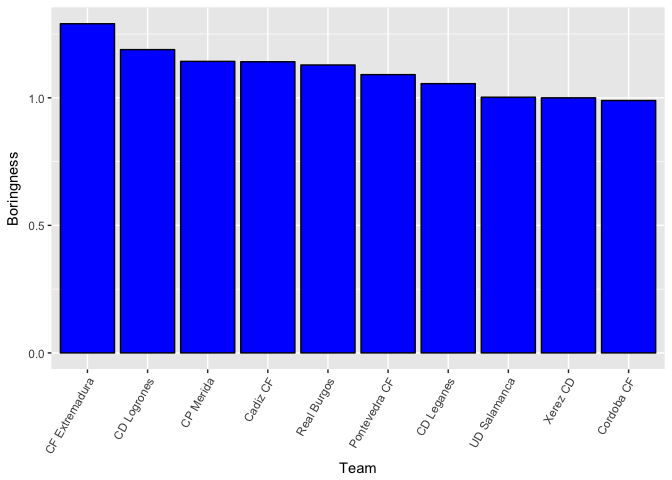

```r
Teams %>%
  arrange(-as.integer(Boringness)) %>%
  .[1:10,] -> tmp
tmp$Team <- factor(tmp$Team, levels=tmp$Team[1:dim(tmp)[1]])
plot=ggplot(data=tmp, aes(x=Team, y=Boringness))
plot + geom_bar(stat = "identity", fill="blue", color="black")+
  theme(axis.text.x=element_text(angle=60, hjust=1))
```

#### ۳. در چند درصد موارد قهرمان نیم فصل در پایان فصل قهرمان شده است؟

##### پاسخ:

قهرمانان هر فصل را حساب کرده ایم. حالا باید قهرمانان هر نیم فصل را هم حساب کنیم. برای حساب کردن جدول نیم فصل، باید اولین بازی از دیدار دوگانه هر دو تیم را در نظر بگیریم و بازی دوم هر دو تیم را حذف کنیم:

```r
laliga %>%
  group_by(Season) %>%
  mutate(year = substr(Date,1,4), month = substr(Date,6,7), day = substr(Date,9,10)) %>%
  select(Season, year, month, day, 3:10) %>%
  arrange(year, month, day) -> laligaHalf

rbind(
  laligaHalf %>%
    select(Season, year, month, day, Team=home, opp=visitor, GF=hgoal, GA=vgoal),
  laligaHalf %>%
    select(Season, year, month, day, Team=visitor, opp=home, GF=vgoal, GA=hgoal)
) %>% mutate (GD=GF-GA) %>%
  arrange(year, month, day)-> plHalf

plHalf %>%
  mutate(tmp=1) -> plHalf

plHalf %>%
  group_by(Season, Team) %>%
  mutate(CumMatch = cumsum(tmp)) -> plHalf

plHalf$tmp=NULL

plHalf %>%
  group_by(Season, Team) %>%
  mutate(numberOfTeams=(n()/2)+1)->plHalf

plHalf %>%
  filter(CumMatch<numberOfTeams) -> plHalf


plHalf %>%
  group_by(Season, Team) %>%
  summarise(Pld= n(), W = sum(GD>0), D=sum(GD==0), L=sum(GD<0), GF=sum(GF), GA=sum(GA), GD=sum(GD)) %>%
  mutate(Pts = 3*W + D) %>%
  arrange(-Season, -Pts, -GD) -> HalfleagueTables

for (n in 1:20)
{
  s=TRUE
  for (i in 1:(dim(HalfleagueTables)[1]-1))
  {
    if ((HalfleagueTables$Season[i]==HalfleagueTables$Season[i+1]) &
        (HalfleagueTables$Pts[i]==HalfleagueTables$Pts[i+1]))
    {
      plHalf%>%
        filter(Season==HalfleagueTables$Season[i] &
                 Team==HalfleagueTables$Team[i] &
                 opp==HalfleagueTables$Team[i+1]) -> data
      GD = sum(data$GD)
      if (GD < 0)
      {
        s=FALSE
        tmp = HalfleagueTables[i,]
        HalfleagueTables[i,]=HalfleagueTables[i+1,]
        HalfleagueTables [i+1,]=tmp
      }
    }
  }
  if (s)
    break
}
HalfleagueTables %>%
  mutate(tmp= 1) -> HalfleagueTables

HalfleagueTables %>%
  group_by(Season) %>%
  mutate(Pos= cumsum(tmp)) -> HalfleagueTables

HalfleagueTables$tmp=NULL

rm (data, tmp, GD, i, n, s)

HalfleagueTables %>%
  group_by(Season) %>%
  slice(1) %>%
  arrange(-Season) -> ChampionsHalf

Champions %>%
  arrange(-Season) -> Champions

for (i in 1:dim(Champions)[1])
  Champions$halfTeam[i] = ChampionsHalf$Team[i]

Champions %>%
  group_by(Pos) %>%
  summarise(n=n(), x=sum(Team==halfTeam)) -> stat

cat((100*stat$x/stat$n),"%")
```

```
## 53.48837 %
```

همانطور که مشخص است، در حدود ۵۳.۴۸ درصد از فصل ها، قهرمان فصل همان قهرمان نیم فصل بوده است.

#### ۴. در بین سال های ۲۰۰۱ تا ۲۰۱۰ گربه سیاه تیم های بزرگ چه تیم هایی بوده است؟

##### پاسخ:

ابتدا داده های بین سال های ۲۰۰۱ تا ۲۰۱۰ را جدا می کنیم. سپس به ازای تیم های بزرگ، تعداد شکست مقابل سایر تیم ها را می شماریم و نمودار آن را رسم میکنیم. می توانیم همه ی این عملیات را در یک تابع به نام BlackCats انجام دهیم و به ازای تیم های بزرگ، این تابع را صدا کنیم:

```r
BlackCats = function(str)
{
  laliga = spain[which(spain$round=="league" & spain$tier==1 &
                         spain$Season>=2001 &  spain$Season<=2010),]

  rbind(
    laliga %>%
      select(Season, Team=home, opp=visitor, GF=hgoal, GA=vgoal),
    laliga %>%
      select(Season, Team=visitor, opp=home, GF=vgoal, GA=hgoal)
  ) %>%
    mutate (GD=GF-GA) %>%
    filter(Team==str) %>%
    group_by(opp) %>%
    summarise(matches=n(), defeats=100*sum(GD<0)/matches) %>%
    filter(matches>=10) %>%
    arrange(-defeats) %>%
    slice(1:10) %>%
    select(Team=opp,Percentage=defeats) ->tmp
  return (tmp)
}
```

نکته ی قابل توجه این است که اگر دو تیم کمتر از ۱۰ بازی با هم داشته باشند، از داده های ما حذف می شوند و در آمار ما تاثیری ندارند.

حالا تابع BlackCats را برای تیم های بزرگ اجرا می کنیم. مثلا برای رئال مادرید:

```r
tmp = BlackCats("Real Madrid")
tmp %>%
  hchart(type="column", hcaes(x=Team, y=Percentage), name="Percentage of Win") %>%
  hc_title(text = "Percentage of Win") %>%
  hc_add_theme(hc_theme_elementary())
```

[interactive chart not shown]

برای رسم همین نمودار با پکیج ggplot خواهیم داشت:

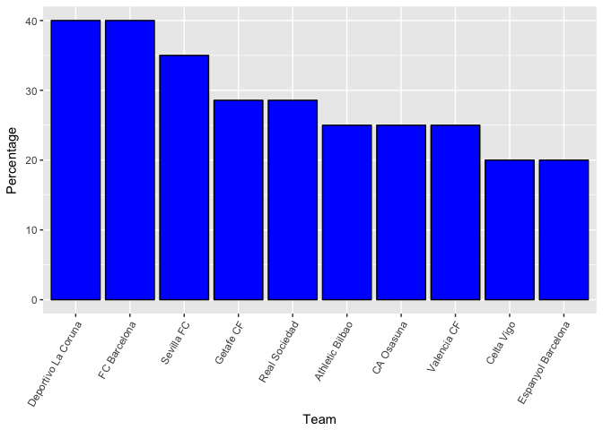

```r
tmp$Team <- factor(tmp$Team, levels=tmp$Team[1:dim(tmp)[1]])
plot=ggplot(data=tmp, aes(x=Team, y=Percentage))
plot + geom_bar(stat = "identity", fill="blue", color="black")+
  theme(axis.text.x=element_text(angle=60, hjust=1))
```

```r
tmp = BlackCats("FC Barcelona")
tmp %>%
  hchart(type="column", hcaes(x=Team, y=Percentage), name="Percentage of Win") %>%
  hc_title(text = "Percentage of Win") %>%
  hc_add_theme(hc_theme_elementary())
```

[interactive chart not shown]

برای رسم همین نمودار با پکیج ggplot خواهیم داشت:

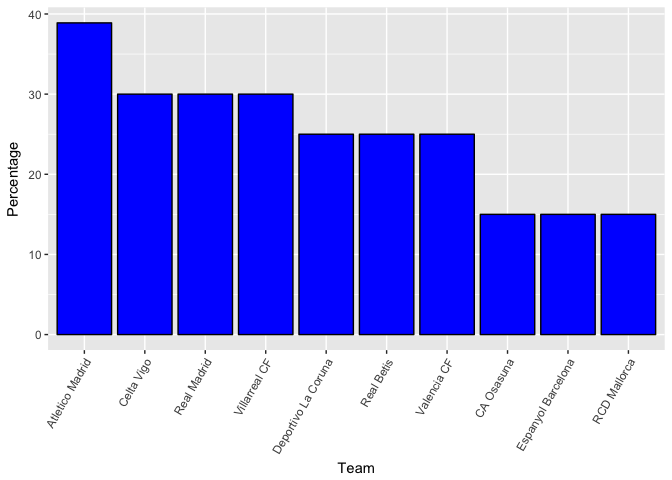

```r
tmp$Team <- factor(tmp$Team, levels=tmp$Team[1:dim(tmp)[1]])
plot=ggplot(data=tmp, aes(x=Team, y=Percentage))
plot + geom_bar(stat = "identity", fill="blue", color="black")+
  theme(axis.text.x=element_text(angle=60, hjust=1))
```

همانطور که مشخص است، گربه سیاه تیم بارسلونا هم تیم Atletico Madrid بوده است.

#### ۵. در تاریخ لالیگا کدام تیم رکورددار زودترین قهرمانی است؟ همچنین کدام تیم مقتدرانه ترین قهرمانی را داشته است؟

##### پاسخ:

برای محاسبه ی مقتدرانه ترین قهرمانی، باید اختلاف امتیاز قهرمان با نائب فهرمان را نگاه کنیم. اما مشکل این است که تعداد بازی ها در تاریخ لیگ ثابت نبوده و امتیاز ها یک دست نیست. بنابراین باید امتیاز ها را به نحوی نرمال کنیم. حداکثر امتیازی که یک تیم می تواند در جدول کسب کند، سه برابر تعداد بازی هایش است. بنابراین اگر امتیاز قهرمان را با Pts1 و امتیاز نائب قهرمان را با Pts2 و تعداد بازی های قهرمان در آن فصل را با n نشان دهیم، اقتدار قهرمان به صورت زیر محاسبه می شود:

$excathedra=\frac{Pts1-Pts2}{3n}$

اختلاف امتیاز قهرمان و نائب قهرمان را قبلا در سوال ۲ حساب کرده ایم. حالا کافی است برای هر قهرمان در تاریخ لالیگا، اقتدار قهرمانی اش را حساب کنیم و برای هر تیم هم بالاترین اقتدارش در سابقه ی قهرمانی هایش را حساب کنیم:

```r
Champions$diffOf1and2 = as.integer(Champions$diffOf1and2)
Champions %>%
  mutate(excathedra=diffOf1and2/(3*Pld)) %>%
  group_by(Team) %>%
  summarise(maxExcathedra=max(excathedra, na.rm = TRUE)) %>%
  arrange(-maxExcathedra) -> tmp
tmp%>%
  hchart(type="column", hcaes(x=Team, y=maxExcathedra)) %>%
  hc_add_theme(hc_theme_elementary())
```

[interactive chart not shown]

برای رسم همین نمودار با پکیج ggplot خواهیم داشت:

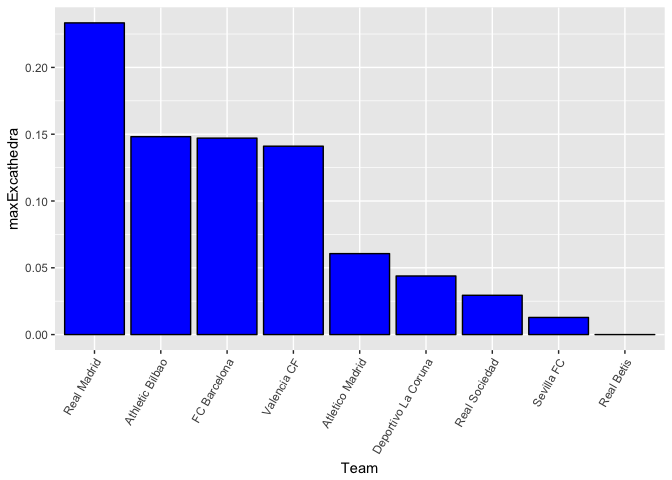

```r
tmp$Team <- factor(tmp$Team, levels=tmp$Team[1:dim(tmp)[1]])
plot=ggplot(data=tmp, aes(x=Team, y=maxExcathedra))
plot + geom_bar(stat = "identity", fill="blue", color="black")+
  theme(axis.text.x=element_text(angle=60, hjust=1))
```

همانطور که مشخص است، مقتدرانه ترین قهرمانی در تاریخ لالیگا مربوط به رئال مادرید است.

حالا می خواهیم زودترین قهرمانی را پیدا کنیم.این بخش کمی دشوارتر است. به همین خاطر مراحل را پله پله توضیح می دهیم. ابتدا مشابه سوال ۳، برای هر تیم، تمام بازی هایش را لیست کرده و بر حسب تاریخ مرتب می کنیم:

```r
laliga %>%
  group_by(Season) %>%
  mutate(year = substr(Date,1,4), month = substr(Date,6,7), day = substr(Date,9,10)) %>%
  select(Season, year, month, day, 3:10) %>%
  arrange(year, month, day) -> laligaHalf

rbind(
  laligaHalf %>%
    select(Season, year, month, day, Team=home,
           opp=visitor, GF=hgoal, GA=vgoal),
  laligaHalf %>%
    select(Season, year, month, day, Team=visitor,
           opp=home, GF=vgoal, GA=hgoal)
) %>% mutate (GD=GF-GA) %>%
  arrange(year, month, day)-> plHalf

rm(laligaHalf)
```

تابع score را به صورت زیر می نویسیم. این تابه یک لیست از تفاوت گل ها میگیرد و لیستی معادل امتیازی که تیم از آن تفاوت گل میگیرد را بر میگرداند:

```r
score = function(GD)
{
  result = vector(mode = typeof(GD[1]), length = length(GD))
  for (i in 1:length(GD))
  {
    if (GD[i]>0)
      result[i]=3
    else if (GD[i]==0)
      result[i]=1
    else
      result[i]=0
  }
  return(result)
}
```

حالا با کمک این تابع، امتیازی که هر تیم از هر بازی اش گرفته را هم به جدولمان اضافه میکنیم. همچنین به ازای هر فصل و هر تیم، امتیاز تجمعی که تیم پس از هر بازی اش، تا آن زمان در فصل گرفته است را هم حساب می کنیم. همچنین تعداد بازی های انجام داده و تعداد بازی های باقی مانده را هم برای هر تیم حساب می کنیم:

```r
plHalf %>%
  mutate(scr=score(GD)) %>%
  mutate(tmp=1) %>%
  group_by(Season, Team) %>%
  arrange(year,month,day) %>%
  mutate(CumScore=cumsum(scr), CumMatch = cumsum(tmp)) %>%
  group_by(Season, Team) %>%
  mutate(totalMatches=n(), remainingMatches=n()-CumMatch) -> plHalf

plHalf$CumMatch=NULL
```

حالا داده ها را بر اساس فصل و تعداد بازی های باقی مانده گروه بندی می کنیم. تیم ها را بر اساس امتیاز در هر گروه رده بندی می کنیم:

```r
plHalf %>%
  group_by(Season, remainingMatches) %>%
  arrange(-CumScore) %>%
  mutate(tmp=1, currentRank=cumsum(tmp)) %>%
  arrange(Season, -remainingMatches, currentRank)->plHalf

plHalf$tmp=NULL
```

تابع diffToNext به گونه ای می نویسیم که امتیاز هر تیم با تیم بعدی اش در جدول را حساب کند:

```r
diffToNext = function(lst)
{
  result = vector(mode = typeof(1L), length = dim(lst)[1])
  for (i in 1:(dim(lst)[1]-1))
  {
    if (lst$remainingMatches[i]==lst$remainingMatches[i+1])
      result[i]=lst$CumScore[i]-lst$CumScore[i+1]
    else
      result[i]=0
  }
  result[dim(lst)[1]]=0
  return(result)
}
```

حالا با کمک این تابع، اختلاف امتیاز هر تیم در هر مرحله از فصل با تیم بعدش را حساب می کنیم:

```r
plHalf$diffToNext = diffToNext(plHalf)
```

حالا از بین داده ها، تیم هایی که در رنک اول ایستاده اند و اختلاف امتیازشان با تیم دوم بیشتر از ۳ برابر بازی های باقی مانده است را جدا می کنیم. این ها تیم هایی هستند که قهرمانی سان قطعی شده است. سپس نسبت تعداد بازی های باقی مانده به کل بازی های تیم در فصل را حساب کرده و نامش را earliness می گذاریم. حالا در هر فصل، تیمی که بیشترین earliness دارد را جدا می کنیم. فصل ها را بر حسب earliness تیم قهرمانشان مرتب کرده و ده فصل اول را نمایش می دهیم:

```r
plHalf$diffToNext = as.integer(plHalf$diffToNext)
plHalf$currentRank = as.integer(plHalf$currentRank)
plHalf$remainingMatches = as.integer(plHalf$remainingMatches)

plHalf %>%
  filter(currentRank==1 & diffToNext>(3*remainingMatches)) %>%
  mutate(earliness=100*remainingMatches/totalMatches) %>%
  group_by(Season) %>%
  arrange(-earliness)%>%
  slice(1) %>%
  arrange(-earliness) %>%
  select(Season, Team, TotalMatches=totalMatches, RemainingMatches=remainingMatches) %>%
  head(10)
```

```
## # A tibble: 10 x 4
## # Groups:   Season [10]
##    Season Team         TotalMatches RemainingMatches
##     <dbl> <chr>               <int>            <int>
##  1   1960 Real Madrid            30                5
##  2   1962 Real Madrid            30                5
##  3   1973 FC Barcelona           34                5
##  4   1974 Real Madrid            34                5
##  5   1990 FC Barcelona           38                5
##  6   1984 FC Barcelona           34                4
##  7   1985 Real Madrid            34                4
##  8   1987 Real Madrid            38                4
##  9   1989 Real Madrid            38                4
## 10   1997 FC Barcelona           38                4
```

همانطور که مشخص است، زودترین قهرمانی مربوط به رئال مادرید در فصل ۱۹۶۰ است. در آن سال هر تیم ۳۰ بازی انجام می داد که رئال مادرید با اختلاف ۵ بازی مانده به انتها، قهرمانی خود را قطعی کرد. این داستان در فصل ۱۹۶۲ هم تکرار شده است.

#### ۶. طولانی ترین نوار پیروزی مساوی و شکست مال چه تیم هایی است؟

##### پاسخ:

```r
plHalf %>%
  arrange(Team, year, month, day) -> plHalf

plHalf %>%
  mutate(cumWins=0, cumDraws=0, cumDefeats=0) -> plHalf

for (i in 1:dim(plHalf)[1])
{
  if (i==1)
  {
    if (plHalf$scr[i]==0)
    {
      plHalf$cumDefeats[i]=1
      plHalf$cumDraws[i]=0
      plHalf$cumWins[i]=0
    }
    else if (plHalf$scr[i]==1)
    {
      plHalf$cumDefeats[i]=0
      plHalf$cumDraws[i]=1
      plHalf$cumWins[i]=0
    }
    else
    {
      plHalf$cumDefeats[i]=0
      plHalf$cumDraws[i]=0
      plHalf$cumWins[i]=1
    }
  }
  else
  {
    if (plHalf$Team[i-1] != plHalf$Team[i])
    {
      if (plHalf$scr[i]==0)
      {
        plHalf$cumDefeats[i]=1
        plHalf$cumDraws[i]=0
        plHalf$cumWins[i]=0
      }
      else if (plHalf$scr[i]==1)
      {
        plHalf$cumDefeats[i]=0
        plHalf$cumDraws[i]=1
        plHalf$cumWins[i]=0
      }
      else
      {
        plHalf$cumDefeats[i]=0
        plHalf$cumDraws[i]=0
        plHalf$cumWins[i]=1
      }
    }
    else if (plHalf$scr[i-1]!=plHalf$scr[i])
    {
      if (plHalf$scr[i]==0)
      {
        plHalf$cumDefeats[i]=1
        plHalf$cumDraws[i]=0
        plHalf$cumWins[i]=0
      }
      else if (plHalf$scr[i]==1)
      {
        plHalf$cumDefeats[i]=0
        plHalf$cumDraws[i]=1
        plHalf$cumWins[i]=0
      }
      else
      {
        plHalf$cumDefeats[i]=0
        plHalf$cumDraws[i]=0
        plHalf$cumWins[i]=1
      }
    }
    else
    {
      if (plHalf$scr[i]==0)
      {
        plHalf$cumDefeats[i]=plHalf$cumDefeats[i-1]+1
        plHalf$cumDraws[i]=0
        plHalf$cumWins[i]=0
      }
      else if (plHalf$scr[i]==1)
      {
        plHalf$cumDefeats[i]=0
        plHalf$cumDraws[i]=plHalf$cumDraws[i-1]+1
        plHalf$cumWins[i]=0
      }
      else
      {
        plHalf$cumDefeats[i]=0
        plHalf$cumDraws[i]=0
        plHalf$cumWins[i]=plHalf$cumWins[i-1]+1
      }
    }
  }
}

plHalf %>%
  group_by(Team) %>%
  summarise(CumDefeats=max(cumDefeats),
            CumDraws=max(cumDraws),
            CumWins=max(cumWins)) ->stat
```

طولانی ترین نوار پیروزی:

```r
stat %>%
  arrange(-CumWins) %>%
  .[1:10,] -> tmp
tmp%>%
  hchart(type="column", hcaes(x=Team, y=CumWins)) %>%
  hc_yAxis(title = list(text = "Maximum Wins In Row")) %>%
  hc_add_theme(hc_theme_elementary())
```

[interactive chart not shown]

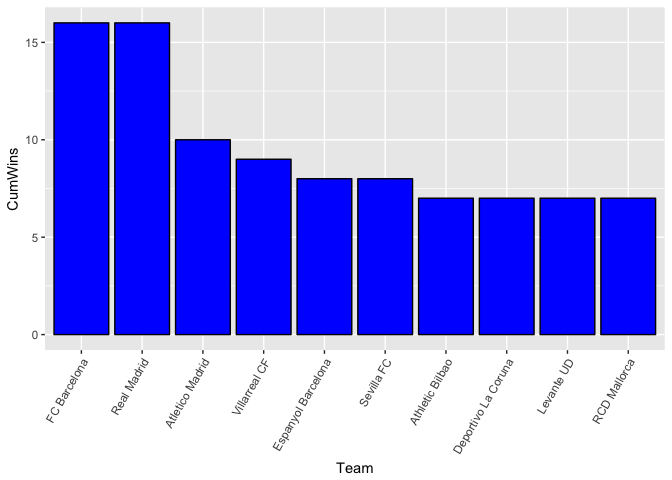

```r
tmp$Team <- factor(tmp$Team, levels=tmp$Team[1:dim(tmp)[1]])
plot=ggplot(data=tmp, aes(x=Team, y=CumWins))
plot + geom_bar(stat = "identity", fill="blue", color="black")+
  theme(axis.text.x=element_text(angle=60, hjust=1))
```

همانطور که مشخص است، طولانی ترین نوار پیروزی، به طور مشترک متعلق به بارسلونا و رئال مادرید است که هر کدام ۱۶ پیروزی پیاپی را تجربه کرده اند. طولانی ترین نوار مساوی:

```r
stat %>%
  arrange(-CumDraws) %>%
  .[1:10,] -> tmp
tmp%>%
  hchart(type="column", hcaes(x=Team, y=CumDraws)) %>%
  hc_yAxis(title = list(text = "Maximum Draws In Row")) %>%
  hc_add_theme(hc_theme_elementary())
```

[interactive chart not shown]

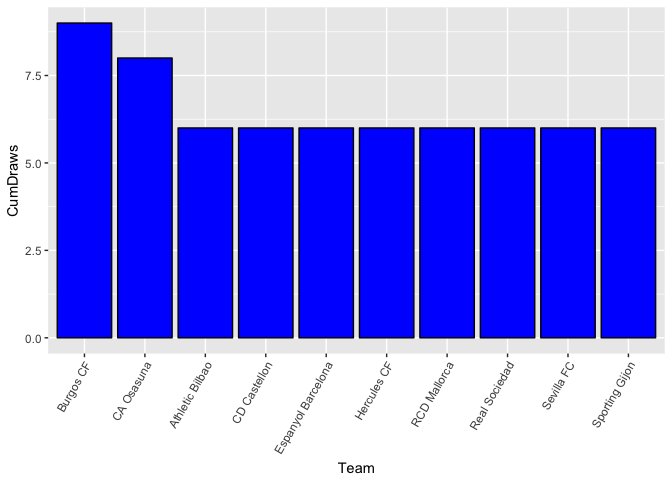

```r
tmp$Team <- factor(tmp$Team, levels=tmp$Team[1:dim(tmp)[1]])
plot=ggplot(data=tmp, aes(x=Team, y=CumDraws))
plot + geom_bar(stat = "identity", fill="blue", color="black")+
  theme(axis.text.x=element_text(angle=60, hjust=1))
```

همانطور که مشخص است طولانی ترین نوار مساوی، متعلق به تیم Burgos CF است که ۹ بار پیاپی تساوی را تجربه کرده است. طولانی ترین نوار باخت:

```r
stat %>%
  arrange(-CumDefeats) %>%
  .[1:10,] -> tmp
tmp%>%
  hchart(type="column", hcaes(x=Team, y=CumDefeats)) %>%
  hc_yAxis(title = list(text = "Maximum Draws In Row")) %>%
  hc_add_theme(hc_theme_elementary())
```

[interactive chart not shown]

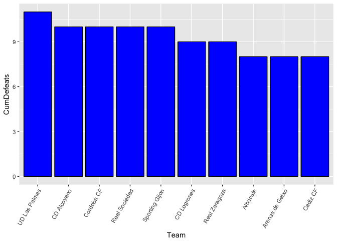

```r
tmp$Team <- factor(tmp$Team, levels=tmp$Team[1:dim(tmp)[1]])
plot=ggplot(data=tmp, aes(x=Team, y=CumDefeats))
plot + geom_bar(stat = "identity", fill="blue", color="black")+
  theme(axis.text.x=element_text(angle=60, hjust=1))
```

همانطور که مشخص است طولانی ترین نوار شکست، مربوط به تیم UD Las Palmas است که ۱۱ بار پیاپی شکست را تجربه کرده است.

#### ۷. زودترین سقوط مال کدام تیم بوده است؟

##### پاسخ:

ایده ی محاسبه ی زودترین سقوط مانند سوال ۵ و ایده ی محاسبه ی زودترین قهرمانی است. منتها به جای اینکه چک کنیم چه زمانی اختلاف امتیاز تیم اول و دوم از سه برابر بازی های باقی مانده بیشتر می شود، باید چک کنیم که چه زمانی اختلاف امتیاز تیم سوم از آخر و چهارم از آخر، بیشتر از سه برابر بازی های باقی مانده می شود:

```r
laliga %>%
  group_by(Season) %>%
  mutate(year = substr(Date,1,4), month = substr(Date,6,7), day = substr(Date,9,10)) %>%
  select(Season, year, month, day, 3:10) %>%
  arrange(year, month, day) -> laligaHalf

rbind(
  laligaHalf %>%
    select(Season, year, month, day, Team=home, opp=visitor, GF=hgoal, GA=vgoal),
  laligaHalf %>%
    select(Season, year, month, day, Team=visitor, opp=home, GF=vgoal, GA=hgoal)
) %>% mutate (GD=GF-GA) %>%
  arrange(year, month, day)-> plHalf

rm(laligaHalf)

score = function(GD)
{
  result = vector(mode = typeof(GD[1]), length = length(GD))
  for (i in 1:length(GD))
  {
    if (GD[i]>0)
      result[i]=3
    else if (GD[i]==0)
      result[i]=1
    else
      result[i]=0
  }
  return(result)
}
plHalf %>%
  mutate(scr=score(GD)) %>%
  mutate(tmp=1) %>%
  group_by(Season, Team) %>%
  arrange(year,month,day) %>%
  mutate(CumScore=cumsum(scr), CumMatch = cumsum(tmp)) %>%
  group_by(Season, Team) %>%
  mutate(totalMatches=n(), remainingMatches=n()-CumMatch) -> plHalf

plHalf$CumMatch=NULL

plHalf %>%
  group_by(Season, remainingMatches) %>%
  arrange(CumScore) %>%
  mutate(tmp=1, currentRank=cumsum(tmp)) %>%
  arrange(Season, -remainingMatches, currentRank)->plHalf

plHalf$tmp=NULL

diffToNext = function(lst)
{
  result = vector(mode = typeof(1L), length = dim(lst)[1])
  for (i in 1:(dim(lst)[1]-1))
  {
    if (lst$remainingMatches[i]==lst$remainingMatches[i+1])
      result[i]=lst$CumScore[i+1]-lst$CumScore[i]
    else
      result[i]=0
  }
  result[dim(lst)[1]]=0
  return(result)
}

plHalf$diffToNext = diffToNext(plHalf)

plHalf$diffToNext = as.integer(plHalf$diffToNext)
plHalf$currentRank = as.integer(plHalf$currentRank)
plHalf$remainingMatches = as.integer(plHalf$remainingMatches)

plHalf %>%
  filter(currentRank==3 & diffToNext>(3*remainingMatches)) %>%
  mutate(earliness=100*remainingMatches/totalMatches) %>%
  group_by(Season) %>%
  arrange(-earliness)%>%
  slice(1) %>%
  arrange(-earliness) %>%
  select(Season, Team, TotalMatches=totalMatches, RemainingMatches=remainingMatches) %>%
  head(10)
```

```
## # A tibble: 10 x 4
## # Groups:   Season [10]
##    Season Team                TotalMatches RemainingMatches
##     <dbl> <chr>                      <int>            <int>
##  1   1950 Real Murcia                   30                4
##  2   1983 Cadiz CF                      34                3
##  3   1941 FC Barcelona                  26                2
##  4   2002 Recreativo Huelva             38                2
##  5   1940 Celta Vigo                    22                1
##  6   1943 Deportivo La Coruna           26                1
##  7   1970 UD Las Palmas                 30                1
##  8   1975 Granada CF                    34                1
##  9   1980 Real Murcia                   34                1
## 10   1985 Hercules CF                   34                1
```

همانطور که مشخص است، تیم Real Murcia در فصل ۱۹۵۰ وقتی که ۴ بازی به انتهای فصل مانده بود، سقوط خود را قطعی کرد و در این زمینه رکورددار محسوب می شود.